# **GREEDY OPTIMIZATION ALGORITHM SERIES**

Spiral vs Artificial Bee Optimization Algorithm

Ikang Fadhli

find me at ikanx101.com

13 March 2023

# *THE ALGORITHMS*

## *Spiral Optimization Algorithm*

*Spiral Optimization Algorithm* adalah salah satu metode *meta heuristic* yang digunakan untuk mencari minimum global dari suatu sistem persamaan.

Algoritmanya mudah dipahami dan intuitif tanpa harus memiliki latar keilmuan tertentu. Proses kerjanya adalah dengan melakukan *random number generating* pada suatu selang dan melakukan rotasi sekaligus kontraksi dengan titik paling minimum pada setiap iterasi sebagai pusatnya.

Berikut adalah algoritmanya:

```
INPUT
  m >= 2 # jumlah titik
  theta  # sudut rotasi (0 <= theta <= 2pi)
  r      # konstraksi
  k_max  # iterasi maksimum
PROCESS
  1 generate m buah titik secara acak
      x_i
  2 initial condition
      k = 0 # untuk keperluan iterasi
  3 cari x_* yang memenuhi
      min(f(x_*))

  4 lakukan rotasi dan konstraksi semua x_i
      x_* sebagai pusat rotasi
      k = k + 1
  5 ulangi proses 3 dan 4
  6 hentikan proses saat k = k_max
      output x_*
```

Berdasarkan algoritma di atas, salah satu proses yang penting adalah melakukan **rotasi** dan **konstraksi** terhadap semua titik yang telah di-*generate*.

Agar memudahkan penjeasan, saya akan memberikan ilustrasi geometri beserta operasi matriks aljabar terkait kedua hal tersebut.

Berikut adalah langkah-langkah yang ditempuh:

1. **Pertama** saya akan membuat program yang bisa merotasi suatu titik berdasarkan suatu $\theta$ tertentu.
2. **Kedua** saya akan memodifikasi program tersebut untuk melakukan rotasi sekaligus konstraksi dengan rasio $r$ tertentu.
3. **Ketiga** saya akan memodifikasi program tersebut untuk melakukan rotasi sekaligus konstraksi dengan **titik pusat rotasi tertentu**.

### Prinsip Kerja: Ilustrasi Geometris

#### Operasi Matriks Rotasi

Misalkan saya memiliki titik $x \in \mathbb{R}^2$. Untuk melakukan rotasi sebesar $\theta$, saya bisa menggunakan suatu matriks $A_{2 \times 2}$ berisi fungsi-fungsi trigonometri sebagai berikut:

$$\begin{bmatrix} x_1 (k+1) \\ x_2 (k+1)
\end{bmatrix} = \begin{bmatrix} \cos{\theta} & -\sin{\theta} \\
\sin{\theta} & \cos{\theta} \end{bmatrix} \begin{bmatrix} x_1 (k) \\
x_2 (k) \end{bmatrix}$$

Berikut adalah uji coba dengan titik sembarang berikut ini:

```r
# uji coba
rot = 12 # berapa banyak rotasi
x0 = rand_titik(0,10) # generate random titik
rotasi_kan(x0,rot)
```

```
## $`Grafik rotasi`
```

[figure not shown]

```
##
## $`Titik-titik rotasi`
##             x          y
## 1    9.222667   4.066999
## 2    5.953565   8.133458
## 3    1.089210  10.020564
## 4   -4.066999   9.222667
## 5   -8.133458   5.953565
## 6  -10.020564   1.089210
## 7   -9.222667  -4.066999
## 8   -5.953565  -8.133458
## 9   -1.089210 -10.020564
## 10   4.066999  -9.222667
## 11   8.133458  -5.953565
## 12  10.020564  -1.089210
```

Uji coba kembali dengan titik sembarang lainnya berikut ini:

```r
# uji coba
rot = 7 # berapa banyak rotasi
x0 = rand_titik(0,10) # generate random titik
rotasi_kan(x0,rot)
```

```
## $`Grafik rotasi`
```

[figure not shown]

```
##
## $`Titik-titik rotasi`
##            x         y
## 1  5.7128865  5.474886
## 2 -0.7185118  7.880050
## 3 -6.6088561  4.351376
## 4 -7.5225969 -2.453973
## 5 -2.7716689 -7.411430
## 6  4.0663824 -6.787929
## 7  7.8423648 -1.052979
```

#### Operasi Matriks Rotasi dan Kontraksi

Jika pada sebelumnya saya **hanya melakukan rotasi**, kali ini saya akan memodifikasi operasi matriks agar melakukan rotasi dan konstraksi secara bersamaan. Untuk melakukan hal tersebut, saya akan definisikan $r,0<r<1$ dan melakukan operasi matriks sebagai berikut:

$$\begin{bmatrix} x_1 (k+1) \\ x_2 (k+1)
\end{bmatrix} = \begin{bmatrix} r \\ r \end{bmatrix} \begin{bmatrix}
\cos{\theta} & -\sin{\theta} \\ \sin{\theta} & \cos{\theta}
\end{bmatrix} \begin{bmatrix} x_1 (k) \\ x_2 (k)
\end{bmatrix}$$

Berikutnya saya akan tunjukkan ilustrasi dari program ini.

Saya akan uji coba untuk sembarang titik berikut ini:

```r
# uji coba
rot = 40 # berapa banyak rotasi
x0 = rand_titik(0,4) # generate random titik
r = .9
rotasi_konstraksi_kan(x0,rot,r)
```

```
## $`Grafik rotasi`
```

[figure not shown]

```
##
## $`Titik-titik rotasi`
##              x             y
## 1   0.69396080  1.4302499080
## 2   0.41550895  1.3690804900
## 3   0.17659977  1.2755022817
## 4  -0.02259628  1.1586825208
## 5  -0.18321837  1.0267941410
## 6  -0.30742977  0.8869418404
## 7  -0.39815377  0.7451365520
## 8  -0.45883519  0.6063099415
## 9  -0.49323054  0.4743608609
## 10 -0.50522800  0.3522261922
## 11 -0.49869731  0.2419691685
## 12 -0.47736885  0.1448790121
```

[output cut: 28 more lines]

Saya akan uji coba kembali untuk sembarang titik lainnya berikut ini:

```r
# uji coba
rot = 6 # berapa banyak rotasi
x0 = rand_titik(0,4) # generate random titik
r = .7
rotasi_konstraksi_kan(x0,rot,r)
```

```
## $`Grafik rotasi`
```

[figure not shown]

```
##
## $`Titik-titik rotasi`
##            x           y
## 1  1.7192519  0.24914004
## 2  0.4507050  1.12944007
## 3 -0.5269399  0.66852943
## 4 -0.5897034 -0.08545503
## 5 -0.1545918 -0.38739794
## 6  0.1807404 -0.22930560
```

**Catatan penting:**

Terlihat bahwa semakin banyak rotasi dan konstraksi yang dilakukan akan membuat titik *initial* **menuju pusat** $(0,0)$.

#### Operasi Matriks Rotasi dan Kontraksi dengan Titik $x^*$ Sebagai Pusatnya

Salah satu prinsip utama dari *spiral optimization algorithm* adalah menjadikan titik $x^*$ sebagai pusat rotasi di setiap iterasinya. Operasi matriksnya adalah sebagai berikut:

$$\begin{bmatrix} x_1 (k+1) \\ x_2 (k+1)
\end{bmatrix} = \begin{bmatrix} x_1^* \\ x_2^* \end{bmatrix} +
\begin{bmatrix} r \\ r \end{bmatrix} \begin{bmatrix} \cos{\theta} &
-\sin{\theta} \\ \sin{\theta} & \cos{\theta} \end{bmatrix} (
\begin{bmatrix} x_1 (k) \\ x_2 (k) \end{bmatrix} - \begin{bmatrix} x_1^*
\\ x_2^* \end{bmatrix} )$$

Berikutnya saya akan tunjukkan ilustrasi dari program ini.

Saya akan coba dengan sembarang titik berikut:

```r
# uji coba
rot = 10 # berapa banyak rotasi
x0 = rand_titik(0,4) # generate random titik
x_bintang = c(0,1) # contoh pusat rotasi
r = .6
rotasi_konstraksi_pusat_kan(x0,rot,r,x_bintang)
```

```
## $`Grafik rotasi`
```

[figure not shown]

```
##
## $`Titik-titik rotasi`
##                x         y
## 1   9.314951e-01 0.6975744
## 2   5.588140e-01 1.1817110
## 3   2.071698e-01 1.2852819
## 4  -4.838562e-05 1.2115416
## 5  -7.462810e-02 1.1026674
## 6  -7.243306e-02 1.0235166
## 7  -4.345338e-02 0.9858702
## 8  -1.610952e-02 0.9778165
## 9   3.762466e-06 0.9835505
## 10  5.803081e-03 0.9920166
```

Saya akan coba kembali dengan sembarang titik lainnya:

```r
# uji coba
rot = 45 # berapa banyak rotasi
x0 = rand_titik(0,10) # generate random titik
x_bintang = c(2,3) # contoh pusat rotasi
r = .87
rotasi_konstraksi_pusat_kan(x0,rot,r,x_bintang)
```

```
## $`Grafik rotasi`
```

[figure not shown]

```
##
## $`Titik-titik rotasi`
##            x        y
## 1  5.7053141 8.975305
## 2  4.4687577 8.596565
## 3  3.4492814 8.120545
## 4  2.6286053 7.587000
## 5  1.9861677 7.027965
## 6  1.5003746 6.468551
## 7  1.1495820 5.927777
## 8  0.9128397 5.419408
## 9  0.7704320 4.952766
## 10 0.7042442 4.533496
## 11 0.6979867 4.164267
## 12 0.7373022 3.845406
```

[output cut: 33 more lines]

# SOAL YANG DIKERJAKAN

## Regresi Linear

Berikut adalah data yang kita gunakan:

```r
df
```

```
##     mpg    wt
## 1  21.0 2.620
## 2  21.0 2.875
## 3  22.8 2.320
## 4  21.4 3.215
## 5  18.7 3.440
## 6  18.1 3.460
## 7  14.3 3.570
## 8  24.4 3.190
## 9  22.8 3.150
## 10 19.2 3.440
## 11 17.8 3.440
## 12 16.4 4.070
## 13 17.3 3.730
## 14 15.2 3.780
```

[output cut: 18 more lines]

Kita akan membuat kurva regresi linear dari data di atas:

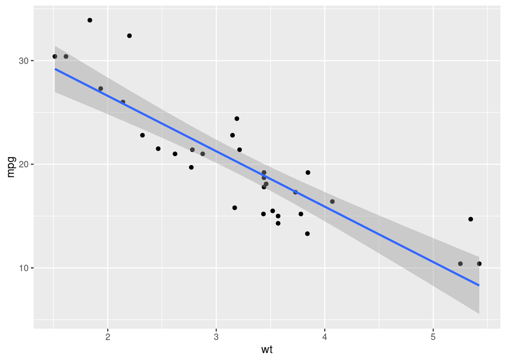

```r
df %>%
  ggplot(aes(y = mpg,
             x = wt)) +
  geom_point() +
  geom_smooth(method = "lm")
```

Dari grafik di atas, jika kita buat persamaan regresi linearnya dengan *base* di **R** adalah sebagai berikut:

```r
model = lm (mpg ~ wt,data = df)

model
```

```
##
## Call:
## lm(formula = mpg ~ wt, data = df)
##
## Coefficients:
## (Intercept)           wt
##      37.285       -5.344
```

Salah satu parameter *goodness of fit* dari model regresi adalah dengan *mean absolute error* (**MAE**). **MAE** dari model di atas kita hitung sebagai berikut:

```r
Metrics::mae(df$mpg, predict(model))
```

```
## [1] 2.340642
```

Pertanyaannya:

> Apakah kita bisa membuat model dengan **MAE** yang lebih kecil dibandingkan persamaan di atas?